# Red Wine Quality by Anav Gupta

# Red Wine Quality by Anav Gupta

# Packages

Before we start exploring the data, we will first load the packages that we will need for this exploration.

# Load the Data

```
'data.frame':   1599 obs. of  13 variables:
 $ X                   : int  1 2 3 4 5 6 7 8 9 10 ...
 $ fixed.acidity       : num  7.4 7.8 7.8 11.2 7.4 7.4 7.9 7.3 7.8 7.5 ...
 $ volatile.acidity    : num  0.7 0.88 0.76 0.28 0.7 0.66 0.6 0.65 0.58 0.5 ...
 $ citric.acid         : num  0 0 0.04 0.56 0 0 0.06 0 0.02 0.36 ...
 $ residual.sugar      : num  1.9 2.6 2.3 1.9 1.9 1.8 1.6 1.2 2 6.1 ...
 $ chlorides           : num  0.076 0.098 0.092 0.075 0.076 0.075 0.069 0.065 0.073 0.071 ...
 $ free.sulfur.dioxide : num  11 25 15 17 11 13 15 15 9 17 ...
 $ total.sulfur.dioxide: num  34 67 54 60 34 40 59 21 18 102 ...
 $ density             : num  0.998 0.997 0.997 0.998 0.998 ...
 $ pH                  : num  3.51 3.2 3.26 3.16 3.51 3.51 3.3 3.39 3.36 3.35 ...
 $ sulphates           : num  0.56 0.68 0.65 0.58 0.56 0.56 0.46 0.47 0.57 0.8 ...
 $ alcohol             : num  9.4 9.8 9.8 9.8 9.4 9.4 9.4 10 9.5 10.5 ...
 $ quality             : int  5 5 5 6 5 5 5 7 7 5 ...
'data.frame':   1599 obs. of  13 variables:
 $ X                   : int  1 2 3 4 5 6 7 8 9 10 ...
 $ fixed.acidity       : num  7.4 7.8 7.8 11.2 7.4 7.4 7.9 7.3 7.8 7.5 ...
 $ volatile.acidity    : num  0.7 0.88 0.76 0.28 0.7 0.66 0.6 0.65 0.58 0.5 ...
 $ citric.acid         : num  0 0 0.04 0.56 0 0 0.06 0 0.02 0.36 ...
 $ residual.sugar      : num  1.9 2.6 2.3 1.9 1.9 1.8 1.6 1.2 2 6.1 ...
 $ chlorides           : num  0.076 0.098 0.092 0.075 0.076 0.075 0.069 0.065 0.073 0.071 ...
 $ free.sulfur.dioxide : num  11 25 15 17 11 13 15 15 9 17 ...
 $ total.sulfur.dioxide: num  34 67 54 60 34 40 59 21 18 102 ...
 $ density             : num  0.998 0.997 0.997 0.998 0.998 ...
 $ pH                  : num  3.51 3.2 3.26 3.16 3.51 3.51 3.3 3.39 3.36 3.35 ...
 $ sulphates           : num  0.56 0.68 0.65 0.58 0.56 0.56 0.46 0.47 0.57 0.8 ...
 $ alcohol             : num  9.4 9.8 9.8 9.8 9.4 9.4 9.4 10 9.5 10.5 ...
 $ quality             : Factor w/ 10 levels "1","2","3","4",..: 5 5 5 6 5 5 5 7 7 5 ...
```

This tidy data set contains 1,599 red wines with 11 variables on the chemical properties of the wine. At least 3 wine experts rated the quality of each wine, providing a rating between 0 (very bad) and 10 (very excellent).

# Univariate Plots Section

```
       X          fixed.acidity   volatile.acidity  citric.acid
 Min.   :   1.0   Min.   : 4.60   Min.   :0.1200   Min.   :0.000
 1st Qu.: 400.5   1st Qu.: 7.10   1st Qu.:0.3900   1st Qu.:0.090
 Median : 800.0   Median : 7.90   Median :0.5200   Median :0.260
 Mean   : 800.0   Mean   : 8.32   Mean   :0.5278   Mean   :0.271
 3rd Qu.:1199.5   3rd Qu.: 9.20   3rd Qu.:0.6400   3rd Qu.:0.420
 Max.   :1599.0   Max.   :15.90   Max.   :1.5800   Max.   :1.000

 residual.sugar     chlorides       free.sulfur.dioxide total.sulfur.dioxide
 Min.   : 0.900   Min.   :0.01200   Min.   : 1.00       Min.   :  6.00
 1st Qu.: 1.900   1st Qu.:0.07000   1st Qu.: 7.00       1st Qu.: 22.00
 Median : 2.200   Median :0.07900   Median :14.00       Median : 38.00
 Mean   : 2.539   Mean   :0.08747   Mean   :15.87       Mean   : 46.47
 3rd Qu.: 2.600   3rd Qu.:0.09000   3rd Qu.:21.00       3rd Qu.: 62.00
 Max.   :15.500   Max.   :0.61100   Max.   :72.00       Max.   :289.00

    density             pH          sulphates         alcohol
 Min.   :0.9901   Min.   :2.740   Min.   :0.3300   Min.   : 8.40
 1st Qu.:0.9956   1st Qu.:3.210   1st Qu.:0.5500   1st Qu.: 9.50
 Median :0.9968   Median :3.310   Median :0.6200   Median :10.20
 Mean   :0.9967   Mean   :3.311   Mean   :0.6581   Mean   :10.42
 3rd Qu.:0.9978   3rd Qu.:3.400   3rd Qu.:0.7300   3rd Qu.:11.10
 Max.   :1.0037   Max.   :4.010   Max.   :2.0000   Max.   :14.90

    quality     quality.num    quality.group
 5      :681   Min.   :3.000   (2,4]:  63
 6      :638   1st Qu.:5.000   (4,6]:1319
 7      :199   Median :6.000   (6,8]: 217
 4      : 53   Mean   :5.636
 8      : 18   3rd Qu.:6.000
 3      : 10   Max.   :8.000
 (Other):  0
```

### Quality

Now lets have a look at the quality variable

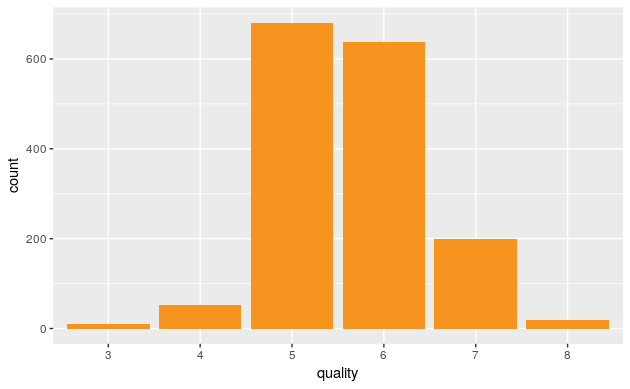

It seems the most of the wines in this sample have quality score of 5 and 6 .

### Fixed.Acidity

```
   Min. 1st Qu.  Median    Mean 3rd Qu.    Max.
   4.60    7.10    7.90    8.32    9.20   15.90
```

```
  (4,5]   (5,6]   (6,7]   (7,8]   (8,9]  (9,10] (10,12] (12,16]
      9      62     291     496     300     188     194      59
  0%  10%  20%  30%  40%  50%  60%  70%  80%  90% 100%
 4.6  6.5  7.0  7.2  7.6  7.9  8.3  8.9  9.7 10.7 15.9
   90%    91%    92%    93%    94%    95%    96%    97%    98%    99%   100%
10.700 10.900 11.100 11.400 11.512 11.800 12.000 12.400 12.700 13.300 15.900
```

The Fixed Acidity of the wine seems to max out around the 6 to 8 units. We can clearly see the presence of the outliers in the data set. This seems appropriate as higher values of fixed acidity will turn the wine more acidic in nature.

### Volatile Acidity

[figure not shown]

```
   Min. 1st Qu.  Median    Mean 3rd Qu.    Max.
 0.1200  0.3900  0.5200  0.5278  0.6400  1.5800

(0.1,0.3] (0.3,0.4] (0.4,0.5] (0.5,0.6] (0.6,0.7] (0.7,0.8]   (0.8,1]
      143       302       314       336       281       119        83
  (1,1.6]
       21
   0%   10%   20%   30%   40%   50%   60%   70%   80%   90%  100%
0.120 0.310 0.370 0.415 0.470 0.520 0.570 0.610 0.660 0.745 1.580
   90%    91%    92%    93%    94%    95%    96%    97%    98%    99%   100%
0.7450 0.7609 0.7800 0.7850 0.8200 0.8400 0.8700 0.9000 0.9600 1.0200 1.5800
```

High levels of Volatile Acidity can lead to a unpleasant and vinegar like taste. This seems to the reason why only few percentage of wines have higher volatile Acidity. Most of the wines seems to contain .4 to .6 levels of volatile acidity.

### Citric Acid

[figure not shown]

```
   Min. 1st Qu.  Median    Mean 3rd Qu.    Max.
  0.000   0.090   0.260   0.271   0.420   1.000
```

It seems that citric Acid is not present in many of wine samples. The citric acid distribution is quite flat. It will be nice to explore the quality of the wines that don’t have any citric Acid.

### Residual sugar

[figure not shown]

```
   Min. 1st Qu.  Median    Mean 3rd Qu.    Max.
  0.900   1.900   2.200   2.539   2.600  15.500
```

It seems that majority of the wines have residual sugar level between 1 and 3. As you can see from the above graph that there are wine samples that far more residual sugar. It will be interesting to compare the quality of wines based on the residual sugar.

### Chlorides

[figure not shown]

```
   Min. 1st Qu.  Median    Mean 3rd Qu.    Max.
0.01200 0.07000 0.07900 0.08747 0.09000 0.61100
```

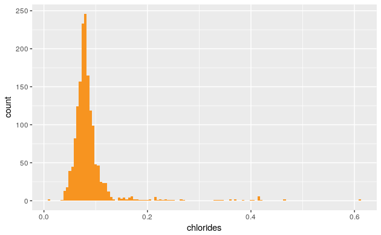

We can clearly see that the chlorides are found in very minute quantities in the wine samples. The chlorides seems to have a Normal distribution with many outliers. About 95 % of the wines contain chlorides in the range of 0.040 to 0.125.

### Free Sulphar Dioxide

[figure not shown]

```
   Min. 1st Qu.  Median    Mean 3rd Qu.    Max.
   1.00    7.00   14.00   15.87   21.00   72.00
```

```
  0%  10%  20%  30%  40%  50%  60%  70%  80%  90% 100%
   1    5    6    9   11   14   16   19   24   31   72
  90%   91%   92%   93%   94%   95%   96%   97%   98%   99%  100%
31.00 31.00 32.00 33.00 34.00 35.00 37.00 39.00 42.00 50.02 72.00
```

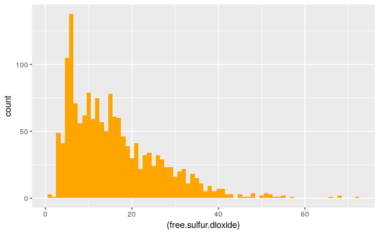

From the graph as well as from the Quintilian function we can clearly see that in majority of the wines(90%) the amount of free sulfur dioxide is with in 31 units. The presence of sulfur dioxide in the low concentration is undetectable, but at free concentration over 50 ppm, the sulfur dioxide become evident in the nose as well as the taste of the wine. I suppose this is why only 1 percent of wines have it’s concentration greater than 50.

### Total Sulfur Dioxide

[figure not shown]

```
   Min. 1st Qu.  Median    Mean 3rd Qu.    Max.
   6.00   22.00   38.00   46.47   62.00  289.00
```

```
   0%   10%   20%   30%   40%   50%   60%   70%   80%   90%  100%
  6.0  14.0  19.0  24.0  30.0  38.0  45.8  55.0  69.0  93.2 289.0
```

Total Sulfur Dioxide is the the total amount of sulfur dioxide in the wine and hence there will be some kind of relation between the free and total sulfur dioxide.

### Density

[figure not shown]

```
   Min. 1st Qu.  Median    Mean 3rd Qu.    Max.
 0.9901  0.9956  0.9968  0.9967  0.9978  1.0037
```

we can clearly see that the density of the wine varies over a narrow range. Median and mean of the density is equal. This suggest that it has a normal distribution.

### pH

[figure not shown]

```
   Min. 1st Qu.  Median    Mean 3rd Qu.    Max.
  2.740   3.210   3.310   3.311   3.400   4.010
```

### Sulphates

[figure not shown]

```
   Min. 1st Qu.  Median    Mean 3rd Qu.    Max.
 0.3300  0.5500  0.6200  0.6581  0.7300  2.0000
```

```
   0%   10%   20%   30%   40%   50%   60%   70%   80%   90%  100%
0.330 0.500 0.540 0.564 0.590 0.620 0.650 0.700 0.760 0.850 2.000
   90%    91%    92%    93%    94%    95%    96%    97%    98%    99%   100%
0.8500 0.8600 0.8700 0.8900 0.9100 0.9300 0.9708 1.0500 1.1300 1.2604 2.0000

  (0,0.5] (0.5,0.6] (0.6,0.7] (0.7,0.8] (0.8,0.9]   (0.9,1]     (1,2]
      178       545       410       237       127        44        58
```

From the histogram as well as from the table information we can clearly see that majority of the wines have 0.5 to 0.7 units of sulphates concentration in the wine.

### Alcohol

[figure not shown]

```
   Min. 1st Qu.  Median    Mean 3rd Qu.    Max.
   8.40    9.50   10.20   10.42   11.10   14.90
```

```
  (8,9]  (9,10] (10,11] (11,12] (12,13] (13,15]
     37     710     444     267     118      23
```

# Univariate Analysis

In this section we will list the analysis of the univariate exploration.

### What is the structure of your dataset?

Our data set consists of 1599 observation having 11 physicochemical inputs and a output that gives the quality of the wine. The quality variable is an ordered factor variable with following levels :

(Worst) —————-> (Best) 1, 2, 3, 4, 5, 6, 6, 7, 8, 9, 10

### What is/are the main feature(s) of interest in your dataset?

We can see that the variables Free sulfur Dioxide and Total Sulfur Dioxide will be connected in some way. In the same manner, Fixed and Total acidity are connected to each other. It will be interesting to find that whether the quantity of alcohol in the wine have any influence on the quality of the wine or not. How does the quantity of Citric Acid, which add freshness and flavor to wines effect the quality of the wine.

### What other features in the dataset do you think will help support your investigation into your feature(s) of interest?

Chlorides, Sugar and Ph are some of the variables that will support my investigation into my features of interest.

### Of the features you investigated, were there any unusual distributions? Did you perform any operations on the data to tidy, adjust, or change the form of the data? If so, why did you do this?

I have converted the quality into a factored variable. This will aid me to visualize the input variable that lead to different quality of wines.

# Bivariate Plots Section

This section will try to explore two variables at a time.

[figure not shown]

From the above graph we can see some significant correlation among the following variables : * pH and Fixed Acidity : - 0.683 * Fixed Acidity and Citric Acid : 0.672 * Density and Fixed Acidity : 0.668 * Free Sulfuric Dioxide and Total Sulfuric Dioxide : 0.668 * Volatile Acidity and Citric Acid : - 0.552 * Citric and pH : - 0.542 * Density and Alcohol : - 0.5

[figure not shown]

Now let test all the physicochemical input of the wine with the Quality (output) of the wine.

### Volatile Acidity and Quality

[output not shown]

[output cut: 89 more lines]

[output not shown]

[figure not shown]

[output not shown]

[output cut: 89 more lines]

[output not shown]

[figure not shown]

We pretty much can’t tell any thing from the above scatter plot. Lets create a box plot for them.

[figure not shown]

From the above Box plot of the Volatile Acidity, we can make some connection between the volatile acidity and the Quality of the wine. In lower quality wines, volatile acidity is very dispersed and the dispersion lowers down as we move to better quality wines. We can see that the median as well as the mean of the volatile acidity in the wine starts to reduce with the increase in the quality of wine. From the Boxplot it seems that .3 to .5 is the ideal range for volatile acidity.

### Fixed Acidity and Quality

[figure not shown]

It’s difficult to sight some trend from the above boxplots. Although it can be said that for each quality of wine 50 percent time, the fixed acidity lies between 7 to 10 units.

### Citric Acid and Quality

[figure not shown]

| quality | n |
| --- | --- |
| 3 | 7 |
| 4 | 43 |
| 5 | 624 |
| 6 | 584 |
| 7 | 191 |
| 8 | 18 |

The trend we can make about the citric acid content and quality of the wine is that the content of citric acid (mean as well as median) increases with the increase in the quality of the wine.

### Ph and Quality

[figure not shown]

From the boxplot you can’t find out much about the quality of the wine from it’s  
pH value. One thing is sure from the boxplot that the pH of the wine generally remains within the range of 3 to 4, with about 50 percent of times within 3.2 to 3.4.

### Residual Sugar vs Quality

[figure not shown]

| quality | gr | n |
| --- | --- | --- |
| 3 | (1,2] | 3 |
| 3 | (2,3] | 4 |
| 3 | (3,4] | 1 |
| 3 | (4,8] | 2 |
| 4 | (1,2] | 20 |
| 4 | (2,3] | 20 |
| 4 | (3,4] | 6 |
| 4 | (4,8] | 6 |
| 4 | (8,16] | 1 |
| 5 | (1,2] | 280 |

[output cut: 19 more lines]

From the boxplot above, we don’t seem to have any kind of relation ship or trend between residual sugar content and the quality of the wine. For 87 percent of times, the residual sugar falls with the range of 1 to 3. Median of the residual sugar content remain constant for all the qualities of wine. some wines with quality 5 and 6 have high amount of residual sugar. More than 50 percent of times for all qualities of wine, residual sugar remains within the range of 2 - 3.

### Chlorides vs Quality

[figure not shown]

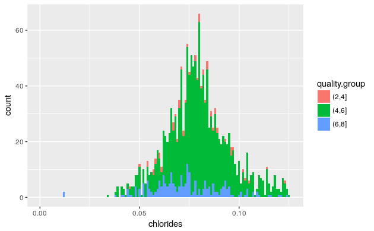

It looks like that there doesn’t seem to be any trend between the quantity of chlorides and the quality of the wine. For most of the wines, the quantity of chloride falls within 0.05 and 0.1 units.

### Free Sulfur Dioxide vs Quality

[figure not shown]

From the Boxplot above it doesn’t seem like that the free sulfur dioxide has any effect on the quality of the wine.

### Total Sulfur Dioxide vs Quality

[figure not shown]

Total Sulfur Dioxide doesn’t seem to have any kind of relationship with the quality of an alcohol. It just so happens that for more that 50 percent of time total sulfur dioxide present in the wine is less than or equal to 50.

### Sulphates vs Quality

[figure not shown]

The median as well as the mean of quantity of the sulphate increases with the increase in the quality of the wine.